# Analiza danych

2026-01-18

# 1 Analiza dotycząca atrakcji

## 1.1 Najpopularniejsze atrakcje

| atrakcja | liczba_skorzystan |
| --- | --- |
| Blockchain Bungee | 5272 |
| Cyber Truck | 5266 |
| AI Horror House | 5240 |
| Maszt 5G | 5209 |
| dziecieca karuzela | 5206 |
| Wróżenie z fusów | 5201 |
| Multiwersum | 5182 |
| Nocny wyscig | 5176 |
| Hyperion | 5148 |
| Symulator kopania kryptowalut | 5066 |

Powyższa tabelka przedstawia atrakcje od najbardziej do najmniej popularnych. Na ogół widać, że poszczególne atrakcje cieszą się podobnym zainteresowaniem.

## 1.2 Porównanie kosztów i zysków

Informacje ogólne o kosztach i zyskach poszczególnych atrakcji

| atrakcja | koszt_utrzymania_h | koszt_przegladow | liczba_skorzystan | przychod_z_biletow | zysk |
| --- | --- | --- | --- | --- | --- |
| Wróżenie z fusów | 10 | 19495.29 | 5201 | 640030 | 568524.7 |
| Multiwersum | 15 | 15008.46 | 5182 | 637810 | 545071.5 |
| Blockchain Bungee | 20 | 6937.59 | 5272 | 644120 | 531742.4 |
| Symulator kopania kryptowalut | 20 | 21966.36 | 5066 | 615650 | 492363.6 |
| dziecieca karuzela | 40 | 14626.82 | 5206 | 649340 | 426473.2 |
| Nocny wyscig | 50 | 2043.64 | 5176 | 639820 | 378976.4 |
| Cyber Truck | 60 | 5990.14 | 5266 | 649190 | 327239.9 |
| AI Horror House | 80 | 15104.96 | 5240 | 638350 | 204045.0 |
| Maszt 5G | 100 | 12085.72 | 5209 | 641960 | 108974.3 |
| Hyperion | 150 | 13602.31 | 5148 | 638910 | -146892.3 |

Informacje konkretniejsze

| atrakcja | całkowity_koszt | zysk |
| --- | --- | --- |
| Wróżenie z fusów | 71505.29 | 568524.7 |
| Multiwersum | 92738.46 | 545071.5 |
| Blockchain Bungee | 112377.59 | 531742.4 |
| Symulator kopania kryptowalut | 123286.36 | 492363.6 |
| dziecieca karuzela | 222866.82 | 426473.2 |
| Nocny wyscig | 260843.64 | 378976.4 |
| Cyber Truck | 321950.14 | 327239.9 |
| AI Horror House | 434304.96 | 204045.0 |
| Maszt 5G | 532985.72 | 108974.3 |
| Hyperion | 785802.31 | -146892.3 |

Jak widać na podstawie tabel, atrakcje są jak najbardziej opłacalne z wyjątkiem: **Hyperion**. W ogólności czasowa niedostępność poszczególnych atrakcji nie ma bezpośredniego wpływu na przychody parku. Wynika to z tego, iż klienci płacą za bilety, a nie za możliwość skorzystania z konkretnej atrakcji. Może to jednak mieć pośredni wpływ na przychody parku, gdyż klient mógłby chcieć odwiedzić park z myślą o skorzystaniu z konkretnych atrakcji, wówczas w momencie gdy takowe atrakcje byłyby niedostępne, to firma nie zarobiłaby za jego bilet.

# 2 Analiza dotycząca liczby obsłużonych klientów w danym miesiącu

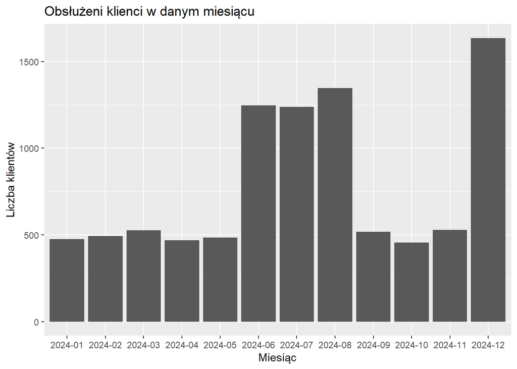

Z wykresu wynika, iż firma ma stałą liczbę klientów w poszczególnych miesiącach oraz miewa miesiące szczytu gdzie ma dużo więcej klientów niż zazwyczaj. Ma to miejsce w wakacje i w święta. Zatem firma ma się dobrze i zdecydowanie nie podupada.

# 3 Analiza dotycząca bezpieczeństwa poszczególnych atrakcji

| atrakcja | liczba_incydentow | srednie_odszkodowanie |
| --- | --- | --- |
| Symulator kopania kryptowalut | 64 | 461.38 |
| AI Horror House | 64 | 462.35 |
| Blockchain Bungee | 63 | 538.97 |
| Hyperion | 62 | 574.63 |
| dziecieca karuzela | 61 | 511.97 |
| Wróżenie z fusów | 59 | 546.39 |
| Maszt 5G | 56 | 549.55 |
| Multiwersum | 48 | 546.88 |
| Cyber Truck | 48 | 524.13 |
| Nocny wyscig | 47 | 498.54 |

Atrakcje dostępne w firmie mają na ogół dość podobną liczbę incydentów. Możemy rozważyć zwiększenie bezpieczeństa tych atrakcji, które mają największą wartość średniego odszkodowania.

# 4 Analiza pensji pracowników w zależności od ich stanowiska

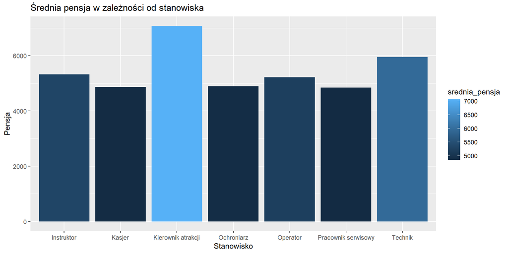

Na podstawie wykresu możemy zauważyć, że najwięcej w tej firmie zarabiają osoby pracujące na stanowisku: **Kierownik atrakcji** i jest to średnio **7070.95zł**.

# 5 Analiza dotycząca liczby wystąpień poszczególnych incydentów

Sprawdźmy, które incydenty mają najczęściej miejsce dla tej firmy.

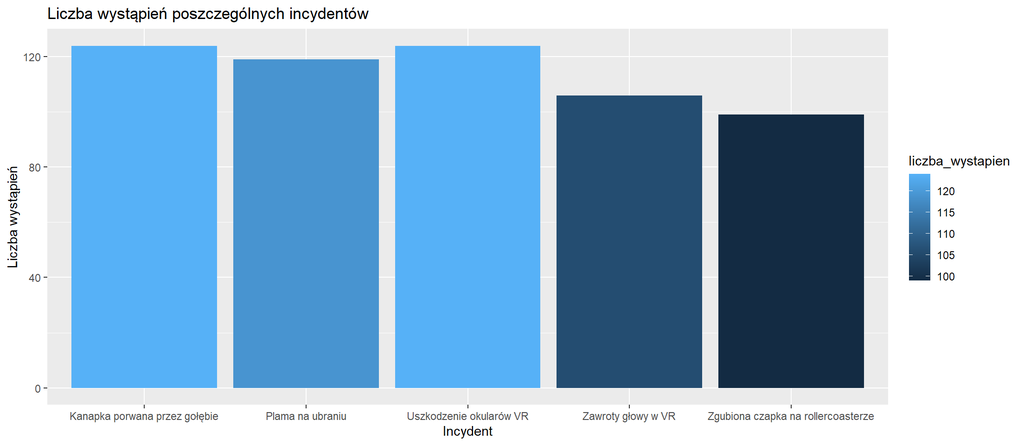

Jak widać do najpopularniejszych incydentów zaliczają się: **Uszkodzenie okularów VR, Kanapka porwana przez gołębie oraz Plama na ubraniu**.

# 6 Analiza dostępnych atrakcji pod kątem awaryjności

| atrakcja | liczba_awarii |
| --- | --- |
| Symulator kopania kryptowalut | 4 |
| Wróżenie z fusów | 4 |
| Maszt 5G | 3 |
| AI Horror House | 2 |
| Cyber Truck | 2 |
| Hyperion | 1 |
| Nocny wyscig | 1 |
| Blockchain Bungee | 1 |
| Multiwersum | 1 |
| dziecieca karuzela | 0 |

Do najbardziej awaryjnych atrakcji zaliczają się: **Symulator kopania kryptowalut, Wróżenie z fusów oraz Maszt 5G**.

# 7 Analiza dotycząca ilości sprzedanych biletów w zależności od ich rodzaju

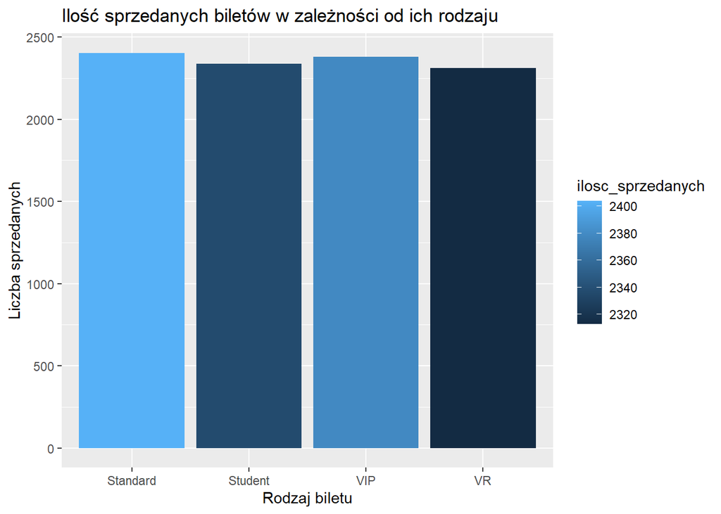

Jak widać na wykresie najlepiej sprzedają się bilety rodzaju: **Standard**.